# Bayes factor design analysis: Manual for the BFDA package

Felix Schönbrodt, Angelika Stefan

2018-10-26

This document demonstrates how to do a design analysis (aka. power analysis) for studies which use Bayes factors as index of evidence. For more details about Bayes Factor Design Analysis (BFDA), see our papers:

> Schönbrodt, F. D. & Wagenmakers, E.-J. (2017). Bayes Factor Design Analysis: Planning for compelling evidence. *Psychonomic Bulletin & Review*. doi:10.3758/s13423-017-1230-y. [[PDF](https://osf.io/d4dcu)][[OSF project with reproducible code](https://osf.io/v7yxp/)]

> Stefan, A. M., Gronau, Q. F., Schönbrodt, F. D., & Wagenmakers, E. (2018). A Tutorial on Bayes Factor Design Analysis with Informed Priors. [PsyArXiv Preprint](https://doi.org/10.31234/osf.io/aqr79)

If you use this package to compute and report your design analysis, please cite it as:

> Schönbrodt, F. D. & Stefan, A. M. (2018). BFDA: An R package for Bayes factor design analysis (version 0.3). Retrieved from https://github.com/nicebread/BFDA

Please note that this package is still a development version; take the results with a grain of salt.

# Installation

The BFDA package is not on CRAN yet, but you can install the development version from Github:

```r
library(devtools)
install_github("nicebread/BFDA", subdir="package")
```

# The general workflow

1. Simulate many hypothetical studies, both under H1 and under H0, using the function `BFDA.sim`
2. Analyze the simulated studies, using the function `BFDA.analyze`
3. Plot the simulated studies (`plot`, `SSD`, `evDens`)
4. Tune your design in a way that you achieve the desired goals with adequate probability (`SSD`)

To summarize, the general workflow is (here shown without parameters; these are discussed later):

```r
sim.H1 <- BFDA.sim(expected.ES = 0.5, ...)
sim.H0 <- BFDA.sim(expected.ES = 0, ...)

BFDA.analyze(sim.H1)
BFDA.analyze(sim.H0)

plot(sim.H1)
plot(sim.H0)

SSD(sim.H1)
SSD(sim.H0)
```

## 1. Simulating hypothetical studies for a prospective design analysis

As we do not know in advance whether H1 or H0 provide a better predictive performance of real world data, we want to evaluate the performance of a design under *both* hypotheses. Hence, we have to simulate a “H1 world” and a “H0 world”:

```r
sim.H1 <- BFDA.sim(expected.ES=0.5, type="t.between", prior=list("Cauchy", list(prior.location=0, prior.scale=1)), n.min=20, n.max=100, alternative="greater", boundary=Inf, B=100, verbose=TRUE, cores=1, stepsize = 10)

sim.H0 <- BFDA.sim(expected.ES=0, type="t.between", prior=list("Cauchy", list(prior.location=0, prior.scale=1)), n.min=20, n.max=100, alternative="greater", boundary=Inf, B=100, verbose=TRUE, cores=1, stepsize = 10)
```

Let’s go through the most important parameters (for a full list of options, see `?BFDA.sim`):

The simulations of the “H1 world” and a “H0 world” should have the same parameters (type, prior, alternative, rscale, boundary, n.min, n.max, B) except the `expected.ES` (in the actual data analysis, we will apply the same test to the data set, regardless whether data came from H0 or H1 (what we don’t know anyway.)).

The BFDA uses the informed t-test functions by [Gronau, Ly, & Wagenmakers (2017)](https://arxiv.org/abs/1704.02479) to compute the between and paired t-test. By default, it uses a central Cauchy distribution with a scale parameter of sqrt(2)/2 as a prior on effect size under H1. For correlations, it uses the source code of the statistics software JASP [(available on Github)](https://github.com/jasp-stats/jasp-desktop/blob/development/JASP-Engine/JASP/R/correlationbayesian.R) which is based on a paper by [Ly, Verhagen & Wagenmakers (2016)](https://www.sciencedirect.com/science/article/pii/S0022249615000383) and a paper by [Ly, Marsman, & Wagenmakers](https://onlinelibrary.wiley.com/doi/full/10.1111/stan.12111). By default, it uses a stretched beta prior on the effect size under H1 with a $\kappa$ parameter of 1, which is equivalent to a uniform prior distribution over the possible correlations.

By default, a full sequential design without evidential stopping threshold is simulated. This means that samples are drawn in a sequential process (n.min + 1 + 1 + …) until the maximum sample size is reached and the hypothesis test is conducted at each stage of this sequential process. The process does not stop when a Bayes factor boundary is reached (e.g., BF(accumulated sample) > 6 or BF(accumulated sample) < 1/6), but when n.max is reached. This allows to extract the results of sequential BFDA procedures with arbitrary thresholds and a maximum N of n.max. With the arguments `design` and `n.max` it is possible to change the procedure to a fixed-N BFDA (e.g., `design="fixed.n", n.max=200` for a fixed-N design with 200 observations) or an open-ended sequential procedure (e.g., `design="sequential", n.max = Inf`).

## 2. Analyze the simulations

For example, we can get the operational characteristics of a **fixed-n design**:

```r
BFDA.analyze(sim.H1, design="fixed", n=50, boundary=6)
```

```
## 37% showed evidence for H1 (BF > 6)
## 61% were inconclusive (0.1667 < BF < 6)
## 2% showed evidence for H0 (BF < 0.1667)
```

```r
BFDA.analyze(sim.H0, design="fixed", n=50, boundary=6)
```

```
## 0% showed evidence for H1 (BF > 6)
## 35% were inconclusive (0.1667 < BF < 6)
## 65% showed evidence for H0 (BF < 0.1667)
```

And for a **sequential design**:

```r
BFDA.analyze(sim.H1, design="sequential", n.min=20, n.max=300, boundary=10)
```

[output not shown]

```r
BFDA.analyze(sim.H1, design="sequential", n.min=20, n.max=100, boundary=10)
```

```
##                                outcome percentage
## 1 Studies terminating at n.max (n=100)        23%
## 2    Studies terminating at a boundary        77%
## 3       --> Terminating at H1 boundary        77%
## 4       --> Terminating at H0 boundary         0%
##
## Of 23% of studies terminating at n.max (n=100):
## 10% showed evidence for H1 (BF > 3)
## 13% were inconclusive (3 > BF > 1/3)
## 0% showed evidence for H0 (BF < 1/3)
##
## Average sample number (ASN) at stopping point (both boundary hits and n.max): n = 67
##
## Sample number quantiles (50/80/90/95%) at stopping point:
## 50% 80% 90% 95%
##  70 100 100 100
```

## 3. Plot the design analysis

### Compare distributions of BFs for a fixed *n*

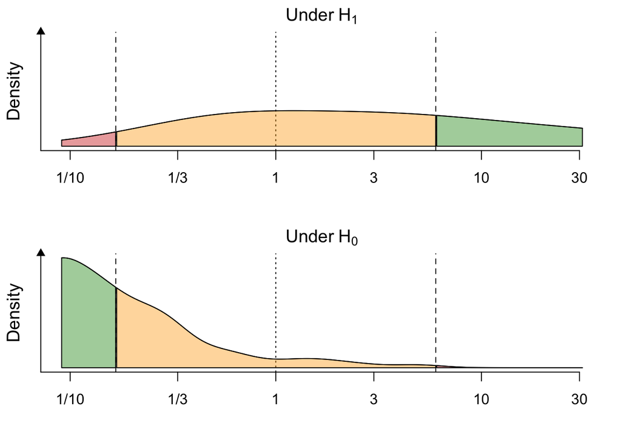

```r
evDens(BFDA.H1=sim.H1, BFDA.H0=sim.H0, n=50, boundary=c(1/6, 6), xlim=c(1/11, 31))
```

### Open-ended sequential design

Under H1:

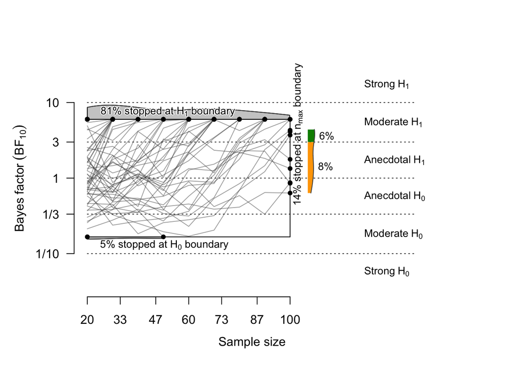

```r
plot(sim.H1, n.min=20, boundary=c(1/6, 6))
```

Under H0:

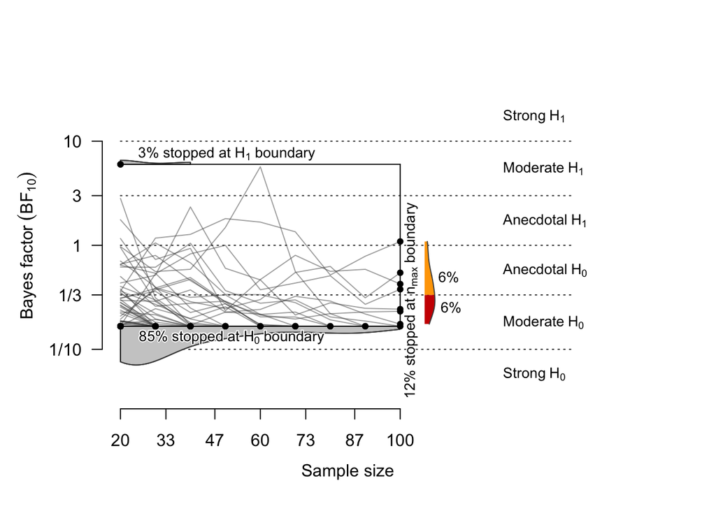

```r
plot(sim.H0, n.min=20, boundary=c(1/6, 6))
```

### Sequential design with n.max and asymmetric boundaries

Under H1:

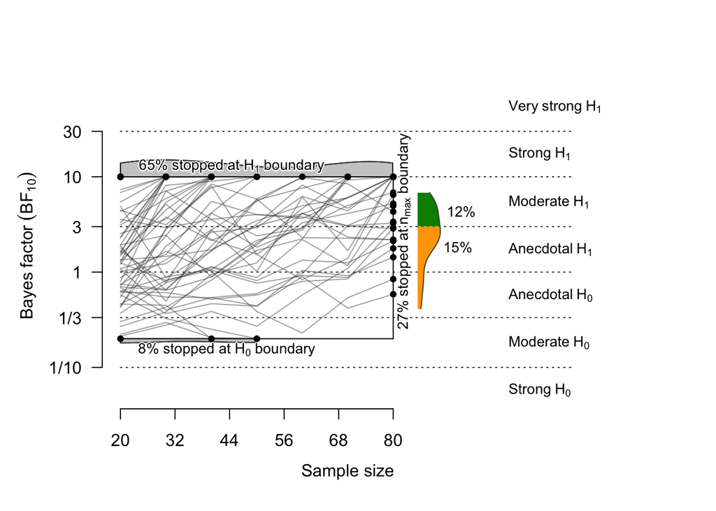

```r
plot(sim.H1, n.min=20, n.max=80, boundary=c(1/5, 10))
```

## 4. Sample Size Determination (SSD)

What sample size do you need to ensure, say, 80% probability that a study design finds an effect of size, say, 0.5 with a BF >= 10?

```r
SSD(sim.H1, power=.80, boundary=c(1/10, 10))
```

```
## A >= 80% (actual: NA%) power achieved at n = NA
## This setting implies long-term rates of:
## NA% inconclusive results and
##    NA% false-negative results.
```

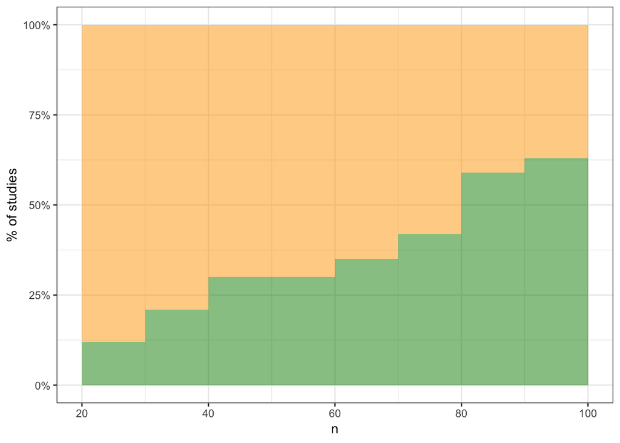

What sample size do I need to have less than 2% of studies with a false positive error, if I set the boundary to 2? **Note: A BF threshold of 2 should never be used! Aim for a BF of at least 5. This is for didactical purposes only!**

```r
SSD(sim.H0, alpha=.02, boundary=c(1/2, 2))
```

```
## A <= 2% (actual: 2%) long-term rate of Type-I errors is achieved at n = 30
## This setting implies long-term rates of:
##    15% inconclusive results and
##    83% true-negative results.
```

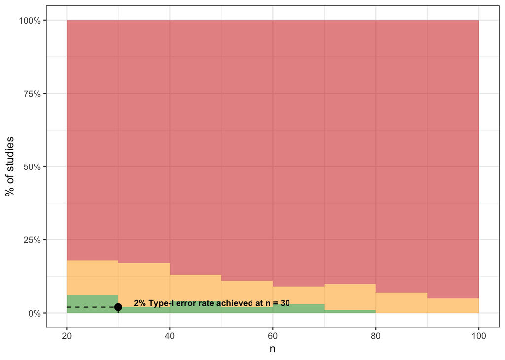

Note: The SSD function automatically detects whether a H1 or a H0 simulation is analyzed. Also note that these numbers of necessary sample sizes are based on simulations and can differ between runs (see the rugged border between the shaded areas in the plot). The larger the number `B` of simulations, the less variable are these estimates.

# Paired t-test: A complete example

The effect size metric is d_z (standardized difference scores).

```r
#devtools::install_github("nicebread/BFDA", subdir="package")
library(BFDA)

# do a sequential design analysis
s1 <- BFDA.sim(expected.ES=0.4, prior=list("t", list(prior.location=0, prior.scale=1, prior.df=10)), n.min=50, stepsize=10, n.max=100, type="t.paired", design="sequential", alternative="greater", B=100, cores=1, verbose=FALSE)
s0 <- BFDA.sim(expected.ES=0, prior=list("t", list(prior.location=0, prior.scale=1, prior.df=10)), n.min=50, stepsize=10, n.max=100, type="t.paired", design="sequential", alternative="greater", B=100, cores=1, verbose=FALSE)

# if no n.min and n.max is provided in the `BFDA.analyze` function, the values from the simulation are taken
BFDA.analyze(s1, design="sequential", boundary=10)
```

```
##                                outcome percentage
## 1 Studies terminating at n.max (n=100)         9%
## 2    Studies terminating at a boundary        91%
## 3       --> Terminating at H1 boundary        91%
## 4       --> Terminating at H0 boundary         0%
##
## Of 9% of studies terminating at n.max (n=100):
## 6% showed evidence for H1 (BF > 3)
## 3% were inconclusive (3 > BF > 1/3)
## 0% showed evidence for H0 (BF < 1/3)
##
## Average sample number (ASN) at stopping point (both boundary hits and n.max): n = 63
##
## Sample number quantiles (50/80/90/95%) at stopping point:
## 50% 80% 90% 95%
##  50  80 100 100
```

```r
BFDA.analyze(s0, design="sequential", boundary=10)
```

```
##                                outcome percentage
## 1 Studies terminating at n.max (n=100)        41%
## 2    Studies terminating at a boundary        59%
## 3       --> Terminating at H1 boundary         2%
## 4       --> Terminating at H0 boundary        57%
##
## Of 41% of studies terminating at n.max (n=100):
## 0% showed evidence for H1 (BF > 3)
## 15% were inconclusive (3 > BF > 1/3)
## 26% showed evidence for H0 (BF < 1/3)
##
## Average sample number (ASN) at stopping point (both boundary hits and n.max): n = 77
##
## Sample number quantiles (50/80/90/95%) at stopping point:
## 50% 80% 90% 95%
##  80 100 100 100
```

```r
BFDA.analyze(s1, design="sequential", boundary=6)
```

```
##                                outcome percentage
## 1 Studies terminating at n.max (n=100)         5%
## 2    Studies terminating at a boundary        95%
## 3       --> Terminating at H1 boundary        95%
## 4       --> Terminating at H0 boundary         0%
##
## Of 5% of studies terminating at n.max (n=100):
## 3% showed evidence for H1 (BF > 3)
## 2% were inconclusive (3 > BF > 1/3)
## 0% showed evidence for H0 (BF < 1/3)
##
## Average sample number (ASN) at stopping point (both boundary hits and n.max): n = 60
##
## Sample number quantiles (50/80/90/95%) at stopping point:
## 50% 80% 90% 95%
##  50  70  90 100
```

```r
BFDA.analyze(s0, design="sequential", boundary=6)
```

```
##                                outcome percentage
## 1 Studies terminating at n.max (n=100)        17%
## 2    Studies terminating at a boundary        83%
## 3       --> Terminating at H1 boundary         4%
## 4       --> Terminating at H0 boundary        79%
##
## Of 17% of studies terminating at n.max (n=100):
## 0% showed evidence for H1 (BF > 3)
## 11% were inconclusive (3 > BF > 1/3)
## 6% showed evidence for H0 (BF < 1/3)
##
## Average sample number (ASN) at stopping point (both boundary hits and n.max): n = 66
##
## Sample number quantiles (50/80/90/95%) at stopping point:
## 50% 80% 90% 95%
##  50  93 100 100
```

[output not shown]

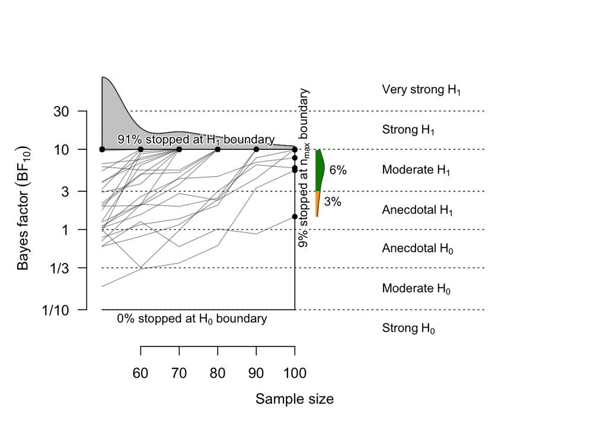

```r
plot(s1)
```

# Correlation: A complete example

The correlation BF implemented in the BFDA package uses a stretched beta prior distribution, as described in:

Wagenmakers, E. J., Verhagen, J., & Ly, A. (2016). How to quantify the evidence for the absence of a correlation. *Behavior Research Methods*, 1–14. http://doi.org/10.3758/s13428-015-0593-0

Here, the correlation is first rescaled to lie between 0 and 1, and then a beta distribution with the parameters $\alpha = \beta = 1/\kappa$ is assigned to it. Then, the beta distribution is transformed back to the (−1, 1) scale and the Bayes factors are calculated as a function of $\kappa$. When $\kappa = 1$, this corresponds to a uniform prior on the correlation coefficient, as in Jeffreys’s default analysis. When $\kappa \rightarrow 0$, H1 becomes indistinguishable from H0 and consequently the Bayes factor is 1. Values of $\kappa$ in between 0 and $\infty$ define an continuous range of different alternative hypotheses that represent different beliefs about the extent to which large values for the correlation are plausible.

The kappa parameter which can be passed to the BFDA.sim function as part of the “prior” argument, corresponds to the “beta prior width” in JASP. Here are some plots for different settings of kappa for the two-sided case:

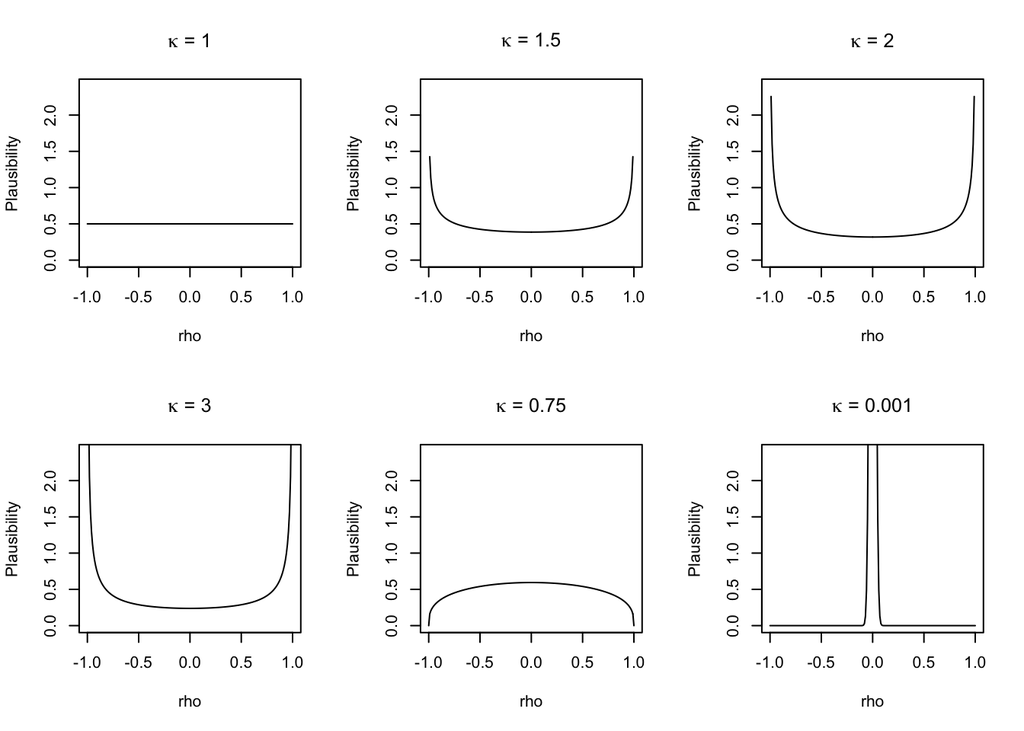

```r
rho <- seq(-1, 1, by=.01)

par(mfrow=c(2, 3))
plot(rho, BFDA:::.priorRho(rho, kappa=1),    main=bquote(kappa*" = 1"),    ylim=c(0, 2.4), type="l", xlab="rho", ylab="Plausibility")
plot(rho, BFDA:::.priorRho(rho, kappa=1.5),  main=bquote(kappa*" = 1.5"),  ylim=c(0, 2.4), type="l", xlab="rho", ylab="Plausibility")
plot(rho, BFDA:::.priorRho(rho, kappa=2),    main=bquote(kappa*" = 2"),    ylim=c(0, 2.4), type="l", xlab="rho", ylab="Plausibility")
plot(rho, BFDA:::.priorRho(rho, kappa=3),    main=bquote(kappa*" = 3"),    ylim=c(0, 2.4), type="l", xlab="rho", ylab="Plausibility")
plot(rho, BFDA:::.priorRho(rho, kappa=0.75), main=bquote(kappa*" = 0.75"), ylim=c(0, 2.4), type="l", xlab="rho", ylab="Plausibility")
plot(rho, BFDA:::.priorRho(rho, kappa=0.001),  main=bquote(kappa*" = 0.001"),  ylim=c(0, 2.4), type="l", xlab="rho", ylab="Plausibility")
```

Here are some plots for different settings of kappa for the one-sided case with a positive directional hypothesis:

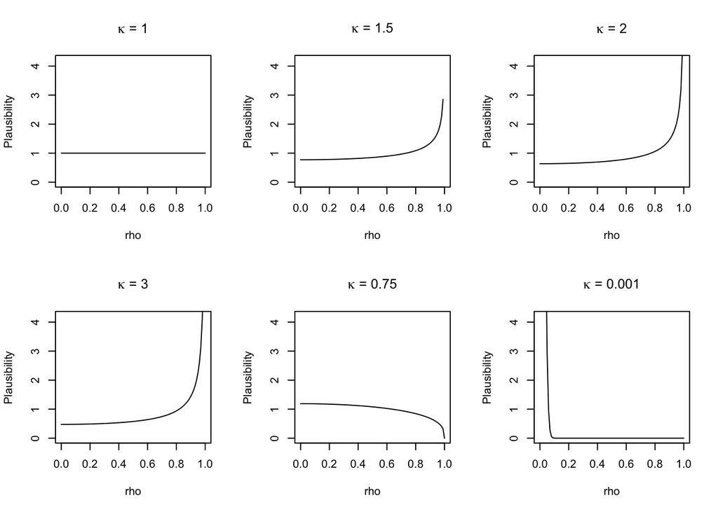

```r
rho <- seq(0, 1, by=.01)

par(mfrow=c(2, 3))
plot(rho, BFDA:::.priorRhoPlus(rho, kappa=1),    main=bquote(kappa*" = 1"),    ylim=c(0, 4.2), type="l", xlab="rho", ylab="Plausibility")
plot(rho, BFDA:::.priorRhoPlus(rho, kappa=1.5),  main=bquote(kappa*" = 1.5"),  ylim=c(0, 4.2), type="l", xlab="rho", ylab="Plausibility")
plot(rho, BFDA:::.priorRhoPlus(rho, kappa=2),    main=bquote(kappa*" = 2"),    ylim=c(0, 4.2), type="l", xlab="rho", ylab="Plausibility")
plot(rho, BFDA:::.priorRhoPlus(rho, kappa=3),    main=bquote(kappa*" = 3"),    ylim=c(0, 4.2), type="l", xlab="rho", ylab="Plausibility")
plot(rho, BFDA:::.priorRhoPlus(rho, kappa=0.75), main=bquote(kappa*" = 0.75"), ylim=c(0, 4.2), type="l", xlab="rho", ylab="Plausibility")
plot(rho, BFDA:::.priorRhoPlus(rho, kappa=0.001),  main=bquote(kappa*" = 0.001"),  ylim=c(0, 4.2), type="l", xlab="rho", ylab="Plausibility")
```

```r
#devtools::install_github("nicebread/BFDA", subdir="package")
library(BFDA)

# do a sequential design analysis
# scale the beta* prior with the kappa parameter
s1 <- BFDA.sim(expected.ES=0.21, prior=list("stretchedbeta", list(prior.kappa=2)), n.min=50, stepsize=10, n.max=100, B=100, type="correlation", design="sequential", alternative="greater", cores=1, verbose=FALSE)
s0 <- BFDA.sim(expected.ES=0, prior=list("stretchedbeta", list(prior.kappa=2)), n.min=50, stepsize=10, n.max=100, B=100, type="correlation", design="sequential", alternative="greater", cores=1, verbose=FALSE)

# if no n.min and n.max is provided in the `BFDA.analyze` function, the values from the simulation are taken
BFDA.analyze(s1, design="sequential", boundary=10)
```

```
##                                outcome percentage
## 1 Studies terminating at n.max (n=100)        59%
## 2    Studies terminating at a boundary        41%
## 3       --> Terminating at H1 boundary        30%
## 4       --> Terminating at H0 boundary        11%
##
## Of 59% of studies terminating at n.max (n=100):
## 10% showed evidence for H1 (BF > 3)
## 39% were inconclusive (3 > BF > 1/3)
## 10% showed evidence for H0 (BF < 1/3)
##
## Average sample number (ASN) at stopping point (both boundary hits and n.max): n = 87
##
## Sample number quantiles (50/80/90/95%) at stopping point:
## 50% 80% 90% 95%
## 100 100 100 100
```

```r
BFDA.analyze(s0, design="sequential", boundary=10)
```

```
##                                outcome percentage
## 1 Studies terminating at n.max (n=100)        27%
## 2    Studies terminating at a boundary        73%
## 3       --> Terminating at H1 boundary         2%
## 4       --> Terminating at H0 boundary        71%
##
## Of 27% of studies terminating at n.max (n=100):
## 1% showed evidence for H1 (BF > 3)
## 6% were inconclusive (3 > BF > 1/3)
## 20% showed evidence for H0 (BF < 1/3)
##
## Average sample number (ASN) at stopping point (both boundary hits and n.max): n = 71
##
## Sample number quantiles (50/80/90/95%) at stopping point:
## 50% 80% 90% 95%
##  60 100 100 100
```

```r
BFDA.analyze(s1, design="sequential", boundary=6)
```

```
##                                outcome percentage
## 1 Studies terminating at n.max (n=100)        39%
## 2    Studies terminating at a boundary        61%
## 3       --> Terminating at H1 boundary        35%
## 4       --> Terminating at H0 boundary        26%
##
## Of 39% of studies terminating at n.max (n=100):
## 4% showed evidence for H1 (BF > 3)
## 32% were inconclusive (3 > BF > 1/3)
## 3% showed evidence for H0 (BF < 1/3)
##
## Average sample number (ASN) at stopping point (both boundary hits and n.max): n = 79
##
## Sample number quantiles (50/80/90/95%) at stopping point:
## 50% 80% 90% 95%
##  80 100 100 100
```

```r
BFDA.analyze(s0, design="sequential", boundary=6)
```

```
##                                outcome percentage
## 1 Studies terminating at n.max (n=100)        12%
## 2    Studies terminating at a boundary        88%
## 3       --> Terminating at H1 boundary         3%
## 4       --> Terminating at H0 boundary        85%
##
## Of 12% of studies terminating at n.max (n=100):
## 0% showed evidence for H1 (BF > 3)
## 5% were inconclusive (3 > BF > 1/3)
## 7% showed evidence for H0 (BF < 1/3)
##
## Average sample number (ASN) at stopping point (both boundary hits and n.max): n = 62
##
## Sample number quantiles (50/80/90/95%) at stopping point:
## 50% 80% 90% 95%
##  50  80 100 100
```

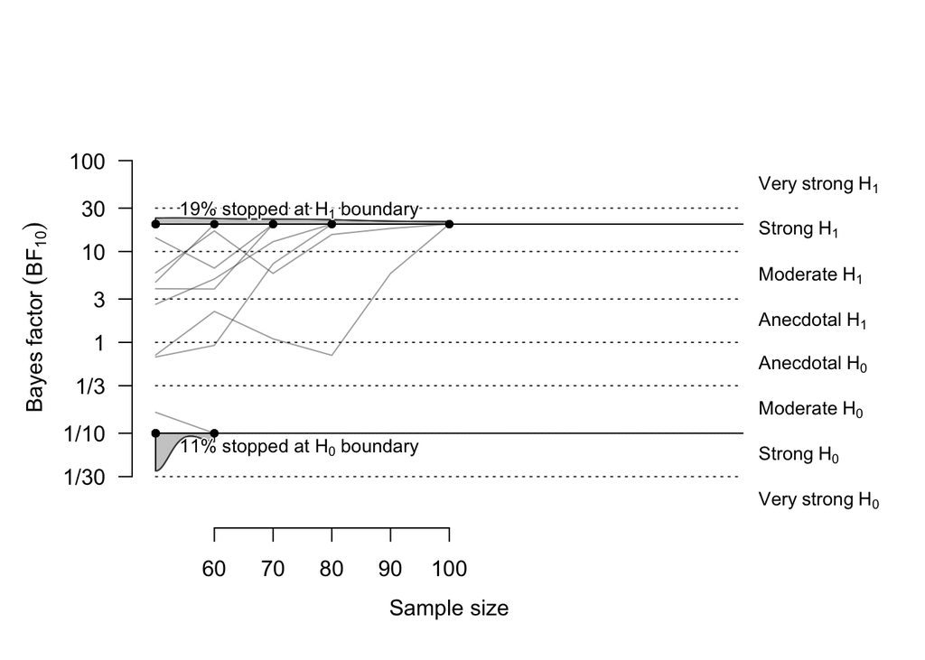

```r
plot(s1, boundary=c(1/10, 20), n.max=150)
```

# Use case: Apply for a grant with sequential sampling

Granting agencies probably want a fixed sample size in the planning stage in order to quantify the amount of funding. For how much participant renumeration should one apply when using a sequential design?

We suggest to determine the requested sample size using two different design analyses:

1. Compute an open-ended SBF design with the expected effect size to get a distribution of sample sizes at stopping point.
2. Compute the 80% quantile of stopping-ns: `n_q80`
3. Evaluate the characteristics of a *SBF+maxN* design with `n.max = n_q80`. Does it have acceptable false positive and false negative error rates? (If not: tune your boundaries). What is the mean and median expected sample size?
4. Apply for a sample size of `n_q80`.

```r
# We use the simulation from above.
# Check the expected sample sizes for an evidential boundary of 10
a1 <- BFDA.analyze(sim.H1, design="sequential", n.min=20, boundary=10)

# --> see 80% quantile in output
a1
```

```
##                                outcome percentage
## 1 Studies terminating at n.max (n=100)        23%
## 2    Studies terminating at a boundary        77%
## 3       --> Terminating at H1 boundary        77%
## 4       --> Terminating at H0 boundary         0%
##
## Of 23% of studies terminating at n.max (n=100):
## 10% showed evidence for H1 (BF > 3)
## 13% were inconclusive (3 > BF > 1/3)
## 0% showed evidence for H0 (BF < 1/3)
##
## Average sample number (ASN) at stopping point (both boundary hits and n.max): n = 67
##
## Sample number quantiles (50/80/90/95%) at stopping point:
## 50% 80% 90% 95%
##  70 100 100 100
```

```r
# Alternative approach: access stopping-ns directly
n_q80 <- ceiling(quantile(a1$endpoint.n, prob=.80))
n_q80
```

```
## 80%
## 100
```

```r
a2.H1 <- BFDA.analyze(sim.H1, design="sequential", n.min=20, n.max=n_q80, boundary=10)
a2.H0 <- BFDA.analyze(sim.H0, design="sequential", n.min=20, n.max=n_q80, boundary=10)
a2.H1
```

```
##                                outcome percentage
## 1 Studies terminating at n.max (n=100)        23%
## 2    Studies terminating at a boundary        77%
## 3       --> Terminating at H1 boundary        77%
## 4       --> Terminating at H0 boundary         0%
##
## Of 23% of studies terminating at n.max (n=100):
## 10% showed evidence for H1 (BF > 3)
## 13% were inconclusive (3 > BF > 1/3)
## 0% showed evidence for H0 (BF < 1/3)
##
## Average sample number (ASN) at stopping point (both boundary hits and n.max): n = 67
##
## Sample number quantiles (50/80/90/95%) at stopping point:
## 50% 80% 90% 95%
##  70 100 100 100
```

```r
a2.H0
```

```
##                                outcome percentage
## 1 Studies terminating at n.max (n=100)        35%
## 2    Studies terminating at a boundary        65%
## 3       --> Terminating at H1 boundary         1%
## 4       --> Terminating at H0 boundary        64%
##
## Of 35% of studies terminating at n.max (n=100):
## 0% showed evidence for H1 (BF > 3)
## 8% were inconclusive (3 > BF > 1/3)
## 27% showed evidence for H0 (BF < 1/3)
##
## Average sample number (ASN) at stopping point (both boundary hits and n.max): n = 68
##
## Sample number quantiles (50/80/90/95%) at stopping point:
## 50% 80% 90% 95%
##  65 100 100 100
```